# R - titanic dataset visualization

# Topic

In this part, we will deal with **titanic** data set. There are 4 main columns in this table namely **Pclass**, **Sex**, **Age**, **Survived**. Try to find any insight information about survival rate of these people (e.g. do their class affect the odds of them surviving? Are women and children really being prioritized for rescue? etc.). You can use any type of graph available on “ggplot2” package: box plot, scatter plot, bar plot, etc. Remember to provide comments on your produced plots.

**Note**: In **Survived** column, 1 denote the customer survived the disaster and vice versa.

## Preparation

```r
# Libraries needed
library(tidyverse)
library(grid)
library(gridExtra)
```

## Load data

```r
# Load data
titanic = read_csv("titanic.csv")

# Select needed columns
dat = titanic %>% select(Pclass, Sex, Age, Survived)

# Missing values handling
na_val = is.na(dat$Age)
dat = dat[!na_val,]
```

```r
dim(dat)
```

```
## [1] 714   4
```

The new dataset has 4 columns and 714 rows

```r
# Support function
author = "Nam Hoang"
draw_pie = function(data, fill_data, title=NULL, author=NULL) {
  # Draw pie chart

  fig = data %>%
    mutate(perc = `n` / sum(`n`)) %>%
    mutate(labels = scales::percent(perc)) %>%
    ggplot(aes(x="", n, fill=fill_data)) +
      geom_bar(stat="identity", width=1, color = "black") +
      geom_text(aes(label = labels),
                position = position_stack(vjust = 0.5)) +
      coord_polar("y", start = 0)

  if (is.null(title)) {
    title = ""
  }

  if (is.null(author)) {
    fig = fig + labs(x=NULL, y=NULL, title=title)
  } else {
    fig = fig + labs(x=NULL, y=NULL, title=title,
                     caption = paste("Author:", author, sep=" "))
  }

  fig = fig + theme_void()
  return (fig)
}
```

## Passenger class

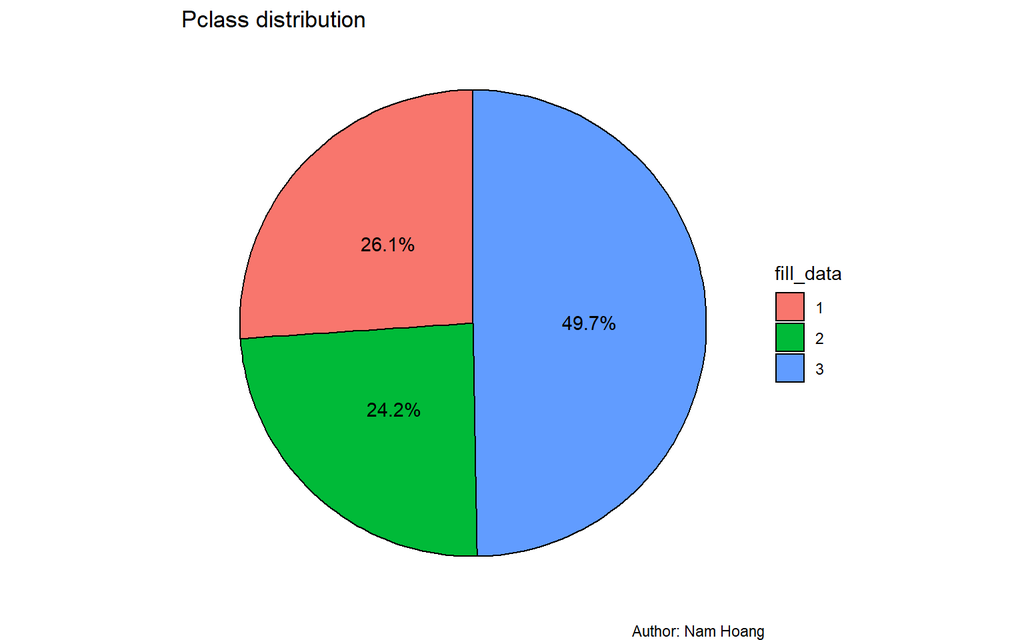

```r
temp = dat %>% mutate(Pclass=as.factor(Pclass)) %>%
  group_by(Pclass) %>% count() %>% ungroup()
draw_pie(temp, temp$Pclass, title="Pclass distribution", author=author)
```

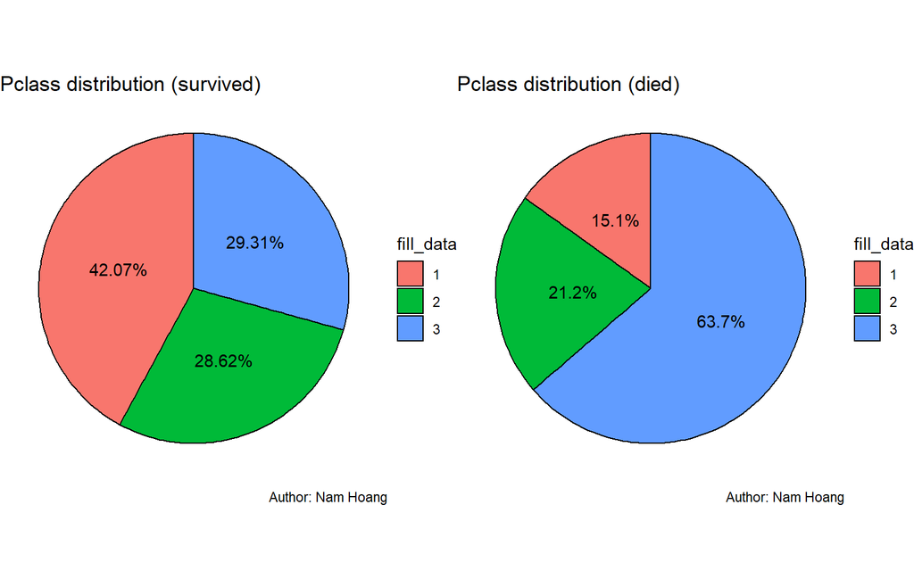

```r
temp = dat %>% filter(Survived==1) %>%
  mutate(Pclass=as.factor(Pclass)) %>%
  group_by(Pclass) %>% count() %>% ungroup()
p1 = draw_pie(temp, temp$Pclass,
              title="Pclass distribution (survived)", author=author)

temp = dat %>% filter(Survived==0) %>%
  mutate(Pclass=as.factor(Pclass)) %>%
  group_by(Pclass) %>% count() %>% ungroup()
p2 = draw_pie(temp, temp$Pclass,
              title="Pclass distribution (died)", author=author)

grid.arrange(p1, p2, ncol=2)
```

## Sex

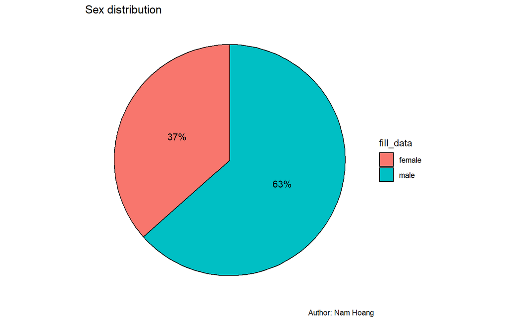

```r
temp = dat %>% group_by(Sex) %>% count() %>% ungroup()
draw_pie(temp, temp$Sex, title="Sex distribution", author=author)
```

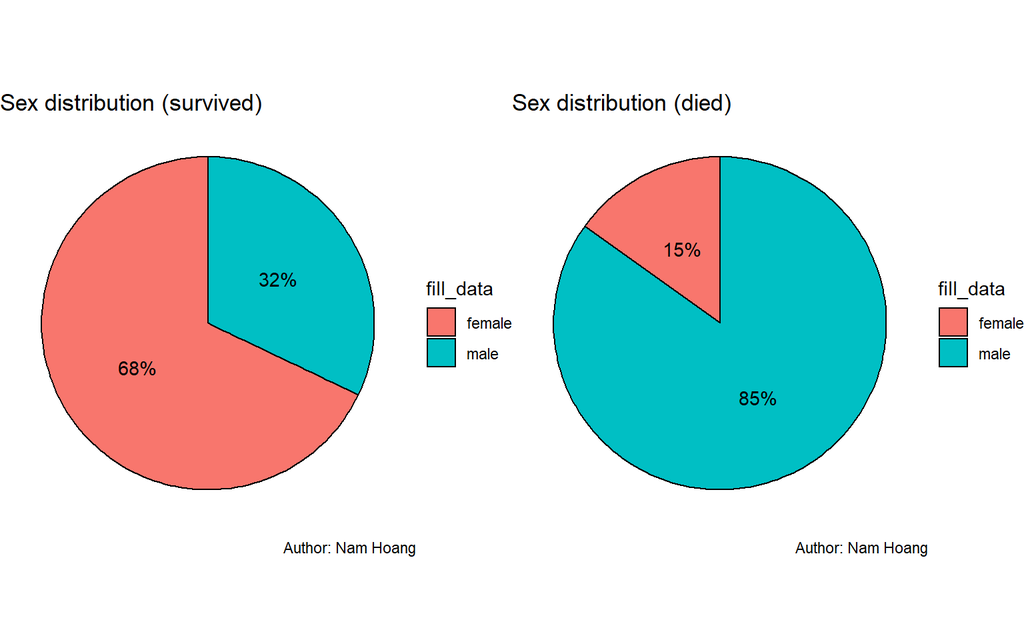

```r
temp = dat %>% filter(Survived==1) %>%
  group_by(Sex) %>% count() %>% ungroup()
p3 = draw_pie(temp, temp$Sex,
              title="Sex distribution (survived)", author=author)

temp = dat %>% filter(Survived==0) %>%
  group_by(Sex) %>% count() %>% ungroup()
p4 = draw_pie(temp, temp$Sex,
              title="Sex distribution (died)", author=author)

grid.arrange(p3, p4, ncol=2)
```

## Age group

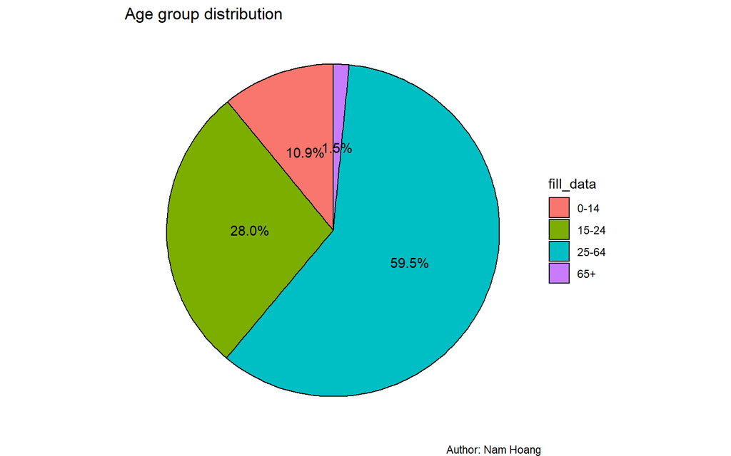

```r
# Age group
age_gr = c("0-14", "15-24", "25-64", "65+")
# age_gr = c("Children", "Youth", "Adults", "Seniors")
temp = dat %>% mutate(Age_group = cut(
  Age, breaks = c(0, 15, 25, 65, Inf), labels = age_gr, right = FALSE)
  ) %>% group_by(Age_group) %>% count() %>%
  ungroup()
draw_pie(temp, temp$Age_group,
         title="Age group distribution", author=author)
```

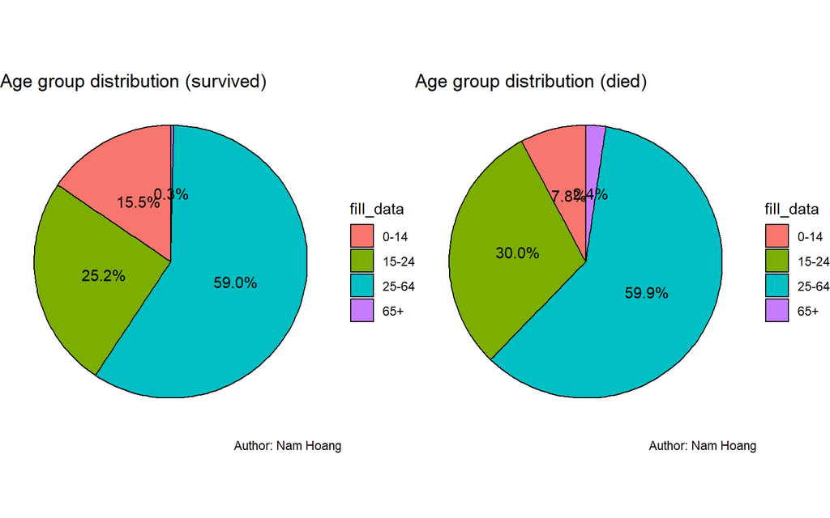

```r
temp = dat %>% filter(Survived==1) %>%
  mutate(Age_group = cut(
  Age, breaks = c(0, 15, 25, 65, Inf), labels = age_gr, right = FALSE)
  ) %>% group_by(Age_group) %>% count() %>%
  ungroup()
p5 = draw_pie(temp, temp$Age_group,
              title="Age group distribution (survived)", author=author)

temp = dat %>% filter(Survived==0) %>%
  mutate(Age_group = cut(
  Age, breaks = c(0, 15, 25, 65, Inf), labels = age_gr, right = FALSE)
  ) %>% group_by(Age_group) %>% count() %>%
  ungroup()
p6 = draw_pie(temp, temp$Age_group,
              title="Age group distribution (died)", author=author)

grid.arrange(p5, p6, ncol=2)
```

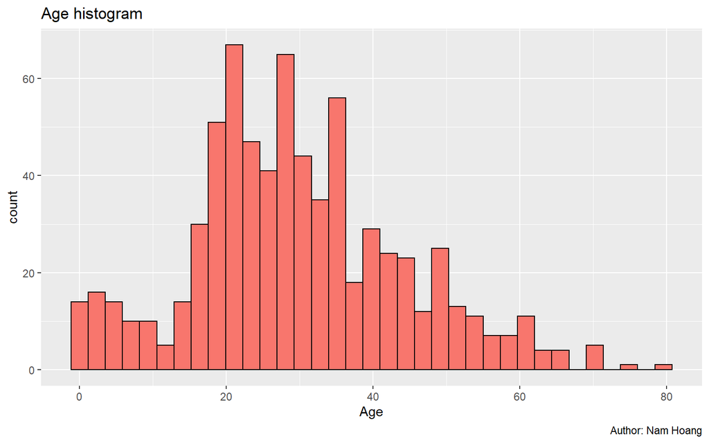

```r
ggplot(dat) +
  geom_histogram(aes(x = Age), bins = 35,
                 color = "black", fill= "#f8766d") +
  labs(title = "Age histogram",
       caption = paste("Author:", author, sep=" "))
```

Most of the passengers are adults (59.5%), people in age group from 15-24 took the second place with 28%. The percentage of survived and died passengers are relatively equal.

## Survived

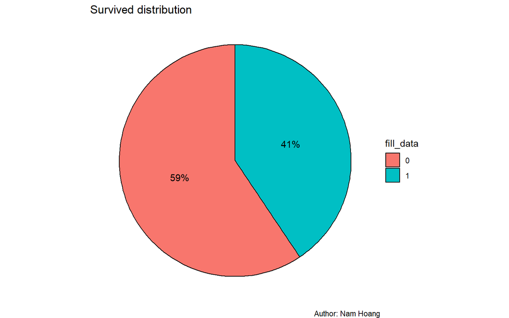

```r
temp = dat %>% mutate(Survived=as.factor(Survived)) %>%
  group_by(Survived) %>% count() %>% ungroup()
draw_pie(temp, temp$Survived, title="Survived distribution", author=author)
```

So far, only 41% of the passengers survived.